# Partial reproduction of Bush et al (2017) Oxic-anoxic regime shifts mediated by feedbacks between biogeochemical processes and microbial community dynamics

Owen Petchey, Rainer M Krug

20 July, 2021

# Introduction

The aims here are:

- Reproduce the results of [Bush et al 2017](https://www.nature.com/articles/s41467-017-00912-x).

And in addition:

- Show how temporal change in oxygen diffusivity causes temporal switches between oxic and anoxic states.
- Show how differences in the functional groups composition alters the ecosystem response to variation in oxygen diffusivity.
- Quantify the amount of hysteresis and nonlinearity in these responses.
- Show how amount of hysteresis and nonlinearity in ecosystem response depends on functional group composition.

These additional results are only presented graphically below, and are not discussed. Some will be presented and discussed in an article associated with this package (*link to be added*).

Please see the *User Guide* vignette for further introduction and general methods.

*Please note that the plotting functions in the `microxanox` package are provided for convenience, and not for production of perfectly formatted print-ready graphs.*

## Code availability

Much of the code used to create the content of this vignette is not shown in the rendered (pdf or html) document. It is available in the [microxanox github repository](https://github.com/opetchey/microxanox/blob/main/vignettes/partial-reproduction-Bushetal2017.Rmd)

# Methods

## Setup R

```r
library(tidyverse)
library(deSolve)
library(rootSolve)
library(here)
if (!require(microxanox)) {
  devtools::load_all(here::here())
}
library(patchwork)

## Set random number generator seed
## Is redundant if there are no stochastic components in the model
set.seed(13)

## should some of the more intense simulations be run...
run_steadystate_sims <- FALSE
options(mc.cores=8)
```

## Set defaults

```r
default_dynamic_model <- bushplus_dynamic_model
default_parameter_values <- new_starter()
## no default_initial_state
default_sim_duration <- 2000
default_sim_sample_interval <- 1
default_log10a_series <- c(log10(default_parameter_values$a_O),
                           log10(default_parameter_values$a_O))
default_event_definition <- event_definition_1
default_event_interval <- 10
default_noise_sigma <- 0
default_minimum_abundances <- rep(1e2, 3)
names(default_minimum_abundances) <- c("CB", "PB", "SB")
```

# Results

## Initial conditions favouring anoxic, no noise, no forcing

Reproduce dynamics when the initial conditions favour the anoxic state (Figure 2a, b in Bush et al. 2017)

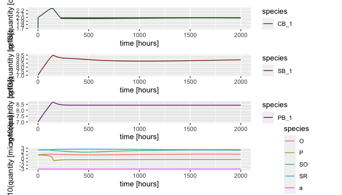

```r
sim_res <- run_simulation(initial_state = new_initial_state(values = "bush_anoxic_fig2ab"))
plot_dynamics(simulation_result = sim_res)
```

Population dynamics seem as in the paper. Resource dynamics fluctuate more than in the paper.

## Initial conditions favouring oxic, no noise, no forcing

Reproduce dynamics when the initial conditions favour the oxic state (Figure 2c, d in Bush et al. 2017)

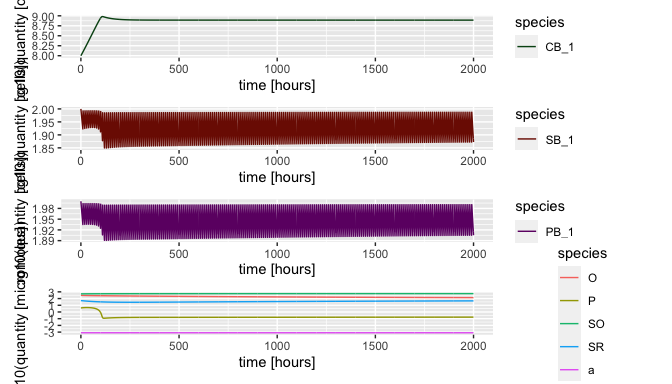

```r
sim_res <- run_simulation(initial_state = new_initial_state(values = "bush_oxic_fig2cd"))

plot_dynamics(sim_res)
```

```r
##ggsave("high_CB.png")
```

## Stable states

Here we find the stable states that correspond to specific values of oxygen diffusivity (parameter $a_0$ / `a_0`). (Code not displayed.)

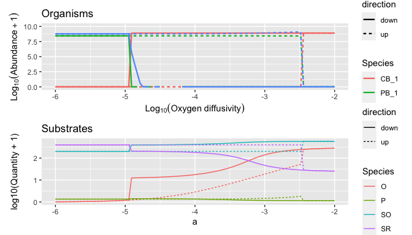

## Temporal state switching

### Anoxic-oxic-anoxic

```r
simulation_duration <- 5000
simulation_sampling_interval <- 10
event_interval_t <- 100

## low-high-low oxgygen diffusivity
lhl_log10a_series <- c(-8, -8, -2, -2, -2, -2, -2, -8, -8)


## run simulation
sim_res <- run_simulation(dynamic_model = bushplus_dynamic_model,
                          initial_state = new_initial_state(values = "bush_anoxic_fig2ab"),
                          log10a_series = lhl_log10a_series,
                          sim_duration = simulation_duration,
                          sim_sample_interval = simulation_sampling_interval,
                          event_interval = event_interval_t)
```

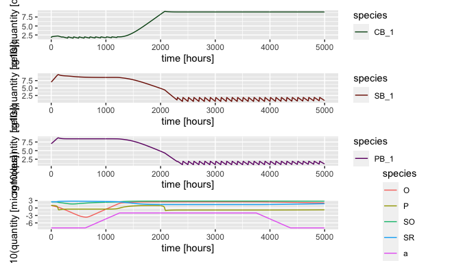

```r
plot_dynamics(lhl_with_defaults)
```

### Oxic-anoxic-oxic

Temporal change in oxygen diffusivity is used to switch the system from oxic to anoxic and back to oxic.

```r
simulation_duration <- 50000

## low-high-low oxgygen diffusivity
hlh_log10a_series <- c(-2, -2, -10, -14, -18, -22, -2, -2, -2)

## run simulation
sim_res <- run_simulation(dynamic_model = bushplus_dynamic_model,
                          initial_state = new_initial_state(values = "bush_oxic_fig2cd"), # init_state_favouring_oxic,
                          log10a_series = hlh_log10a_series,
                          sim_duration = simulation_duration,
                          sim_sample_interval = simulation_sampling_interval,
                          event_interval = event_interval_t)
```

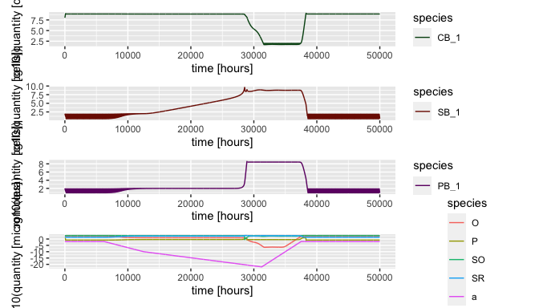

```r
plot_dynamics(hlh_with_defaults)
```

## Functional group composition and nature of response

In this section we get the stable states corresponding to specific values of oxygen diffusivity (parameter $a_0$ / `a_0`), for each combination of presence/absence of the functional groups.

Here we set the conditions common to all simulations:

```r
ssfind_minimum_abundances <- rep(0, 3)
names(ssfind_minimum_abundances) <- c("CB", "PB", "SB")
ssfind_simulation_duration <- 50000
ssfind_simulation_sampling_interval <- ssfind_simulation_duration
ssfind_event_interval <- ssfind_simulation_duration
ssfind_parameters <- new_starter(n_CB = 1,
                                 n_PB = 1,
                                 n_SB = 1,
                                 values_initial_state = "bush_ssfig3")
# ssfind_init_state <- c(N_CB = NA,
#                        N_PB = NA,
#                        N_SB = NA,
#                        SO = 500,
#                        SR = 50,
#                        O = 30,
#                        P = 10)
##ssfind_init_state <- default_initial_state
##ssfind_init_state <- return_anoxic_1strain_initial_state()
#ssfind_init_state <- c(N_CB = NA, #this one is varied
#                       N_PB = 1e8,
#                       N_SB = 1e8,
#                       SO = 200,
#                       SR = 200,
#                       O = 10,
#                       P = 9.5)
grid_num_a <- 100
a_Os <- 10^seq(-6, -2, length=grid_num_a)
grid_num_N <- 2
```

### No organisms

```r
initial_CBs <- 0
initial_PBs <- 0
initial_SBs <- 0
expt <- expand.grid(N_CB = initial_CBs,
                    N_PB = initial_PBs,
                    N_SB = initial_SBs,
                    a_O = a_Os)
ss_no_biology <- ss_by_a_N(expt, ssfind_parameters)
```

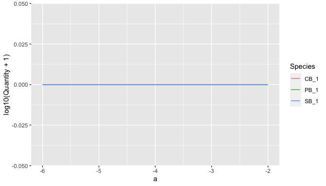

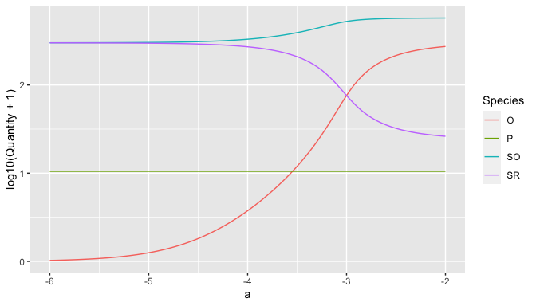

### CB

```r
initial_CBs <- 10^seq(0, 10, length=grid_num_N)
initial_PBs <- 0
initial_SBs <- 0
expt <- expand.grid(N_CB = initial_CBs,
                    N_PB = initial_PBs,
                    N_SB = initial_SBs,
                    a_O = a_Os)
ss_only_CB <- ss_by_a_N(expt, ssfind_parameters)
```

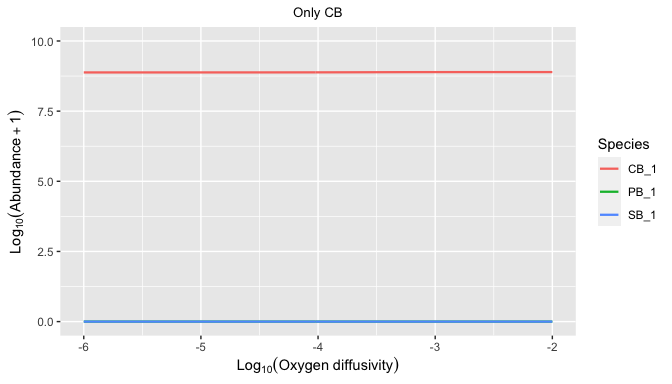

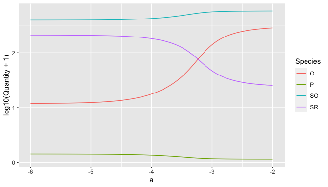

### SB

```r
initial_CBs <- 0  # this one is varied
initial_PBs <- 0
initial_SBs <- 10^seq(0, 8, length=grid_num_N)
expt <- expand.grid(N_CB = initial_CBs,
                    N_PB = initial_PBs,
                    N_SB = initial_SBs,
                    a_O = a_Os)
ss_only_SB <- ss_by_a_N(expt, ssfind_parameters)
```

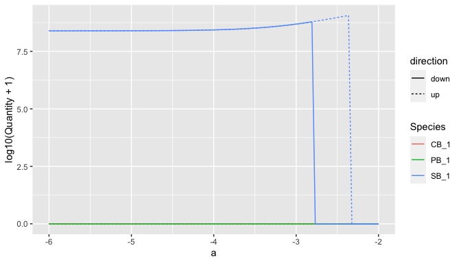

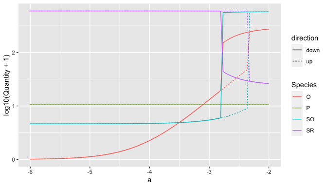

### PB

```r
initial_CBs <- 0  # this one is varied
initial_PBs <- 10^seq(0, 8, length=grid_num_N)
initial_SBs <- 0
expt <- expand.grid(N_CB = initial_CBs,
                    N_PB = initial_PBs,
                    N_SB = initial_SBs,
                    a_O = a_Os)
ss_only_PB <- ss_by_a_N(expt, ssfind_parameters)
```

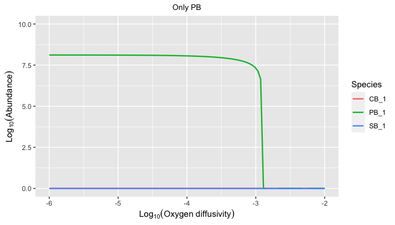

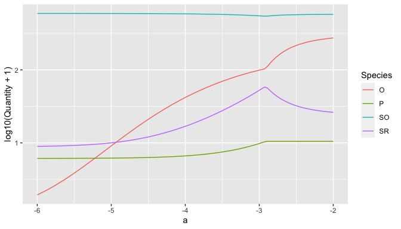

### SB and PB

```r
initial_CBs <- 0  # this one is varied
initial_PBs <- 10^seq(0, 8, length=grid_num_N)
initial_SBs <- 0
expt <- expand.grid(N_CB = initial_CBs,
                    N_PB = initial_PBs,
                    N_SB = initial_SBs,
                    a_O = a_Os)
expt$N_SB <- expt$N_PB
ss_only_SB_PB <- ss_by_a_N(expt, ssfind_parameters)
```

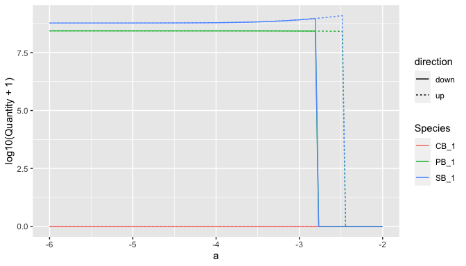

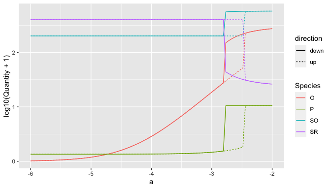

### SB and CB

```r
initial_CBs <- 10^seq(0, 10, length=grid_num_N)
initial_PBs <- 0
initial_SBs <- 10^8
expt <- expand.grid(N_CB = initial_CBs,
                    N_PB = initial_PBs,
                    N_SB = initial_SBs,
                    a_O = a_Os)
#expt$N_SB <- expt$N_CB
ss_only_SB_CB <- ss_by_a_N(expt, ssfind_parameters)
```

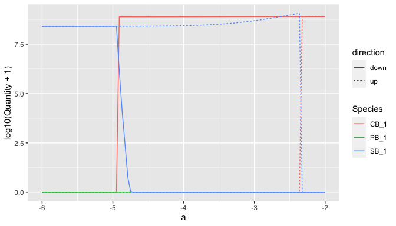

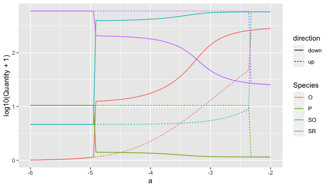

### CB and PB

```r
initial_CBs <- 10^seq(0, 10, length=grid_num_N)  # this one is varied
initial_PBs <- 10^8
initial_SBs <- 0
expt <- expand.grid(N_CB = initial_CBs,
                    N_PB = initial_PBs,
                    N_SB = initial_SBs,
                    a_O = a_Os)
expt$N_CB <- expt$N_PB
ss_only_CB_PB <- ss_by_a_N(expt, ssfind_parameters)
```

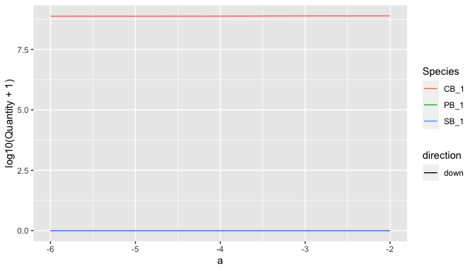

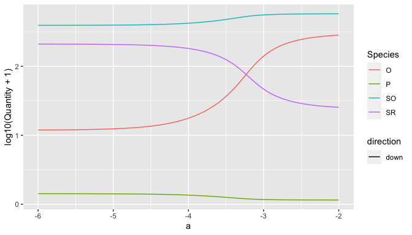

### CB, SB, and PB

```r
initial_CBs <- 10^seq(0, 10, length=grid_num_N)
initial_PBs <- 1e8
initial_SBs <- 1e8
expt <- expand.grid(N_CB = initial_CBs,
                    N_PB = initial_PBs,
                    N_SB = initial_SBs,
                    a_O = a_Os)
ss_CB_SB_PB <- ss_by_a_N(expt, ssfind_parameters)
```

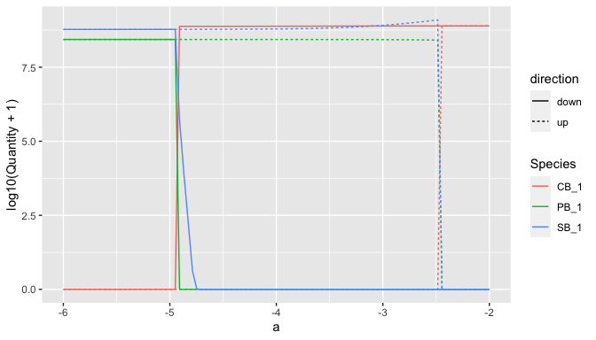

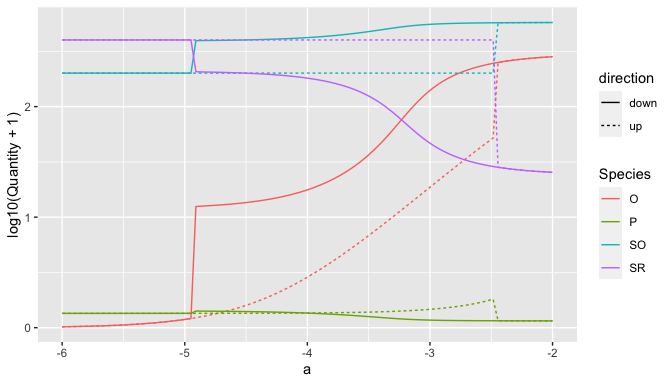

## Stability measures

Note that here, “stability measures” quantify characteristics of the state-environment relationship (i.e. nonlinearity and hysteresis). The measures of non-linearity and hysteresis were used in [Garnier et al (2020) (link to online article)](https://onlinelibrary.wiley.com/doi/abs/10.1002/ece3.6294).

Not much code is shown because all is rather standard data wrangling. The unique work is done by the `get_stability_measures` function, which is demonstrated in the User Guide.

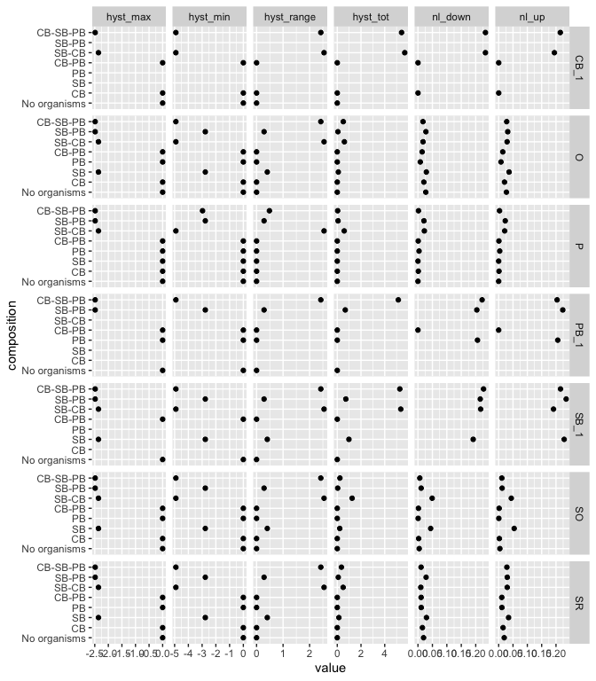

### Nonlinearity

This is the amount of non-linearity in the (steady) state-environment relationship. Here, the environment is oxygen diffusivity $a_0$ / `a_0`.

#### Organism nonlinearity

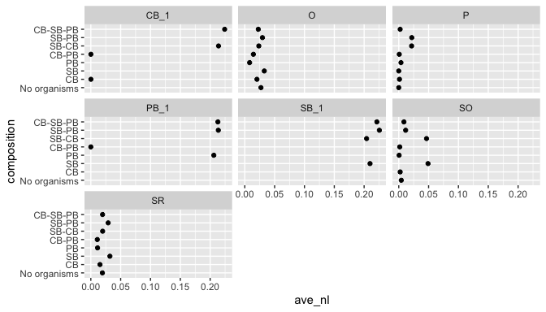

#### Substrate nonlinearity

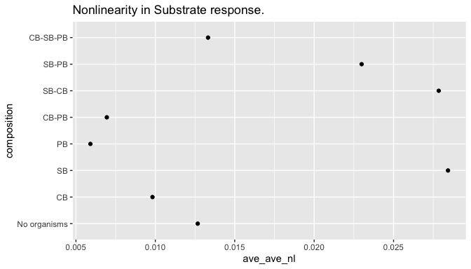

#### Average organism nonlinearity

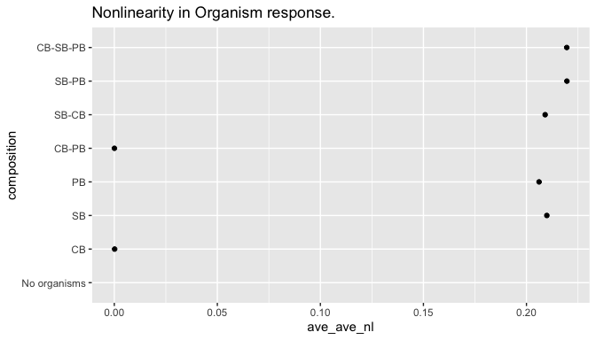

#### System nonlinearity

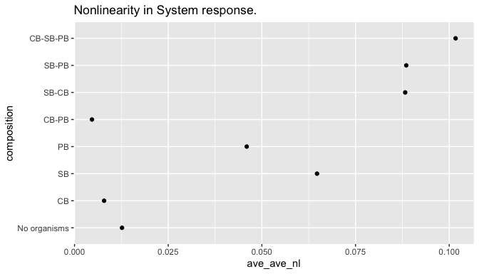

### Hysteresis

#### Substrate hysteresis

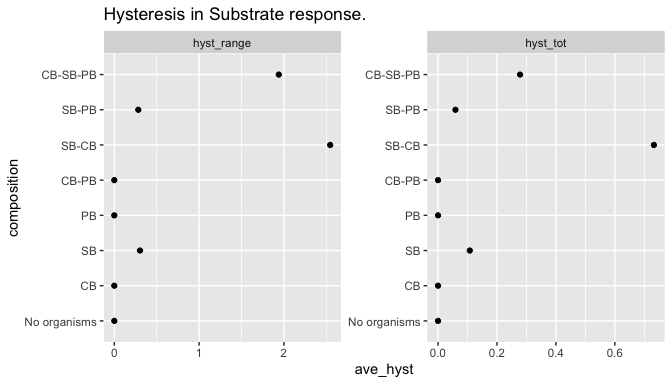

#### Organism hysteresis

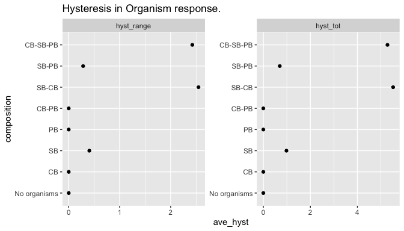

#### System hysteresis (separate)

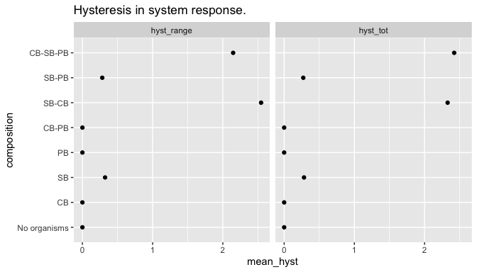

#### System hysteresis (combined)

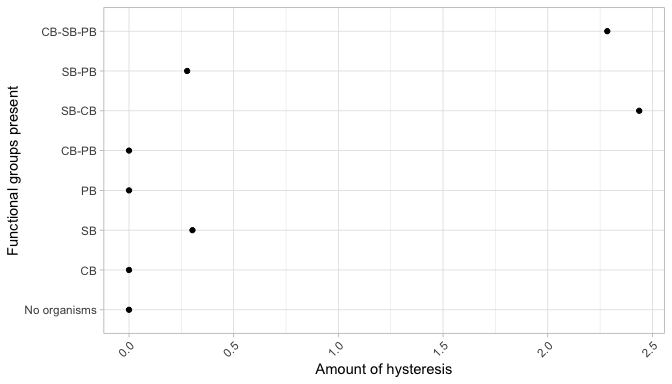